# **Complements of Probability and Statistics** iDBA

# 3 Data structures, text, date and time manipulation

In R we have objects which are functions and objects which are data.

- Function examples:
  - `sin()`
  - `integrate()`
  - `plot()`
  - `paste()`
- Data examples:
  - 42
  - 1:5
  - “R”
  - matrix(1:12, nrow=4, ncol=3)
  - data.frame(a=1:5, tmt=c(“a”,“b”,“a”,“b”,“a”))
  - list(x=2, y=“abc”, x=1:10)

## 3.1 Data structures

### 3.1.1 Vector

```r
> # Vector of numbers, e.g:
> c(1,1.2,pi,exp(1))
```

```
## [1] 1.000000 1.200000 3.141593 2.718282
```

```r
>
> # We can have vectors of other things too, e.g:
> c(TRUE,1==2)
```

```
## [1]  TRUE FALSE
```

```r
> c("a","ab","abc")
```

```
## [1] "a"   "ab"  "abc"
```

```r
>
> # But not combinations, e.g:
> c("a",5,1==2)
```

```
## [1] "a"     "5"     "FALSE"
```

```r
> # Notice that R just turned everything into characters!
```

**Constructing vectors**

```r
> # Integers from 9 to 17
> x<-9:17
> x
```

```
## [1]  9 10 11 12 13 14 15 16 17
```

```r
>
> # A sequence of 11 numbers from 0 to 1
> y<-seq(0,1,length=11)
> y
```

```
##  [1] 0.0 0.1 0.2 0.3 0.4 0.5 0.6 0.7 0.8 0.9 1.0
```

```r
>
> # The same number or the same vector several times
> z<-rep(1:2, 5)
> z
```

```
##  [1] 1 2 1 2 1 2 1 2 1 2
```

```r
>
> # Combine numbers, vectors or both into a new vector
> xz10<-c(x,z,10)
> xz10
```

```
##  [1]  9 10 11 12 13 14 15 16 17  1  2  1  2  1  2  1  2  1  2 10
```

**Index and logical index**: important for optimal use of R

```r
> # Define a vector with integers from (-5) to 5 and extract the numbers with absolute value less than 3:
> x<- (-5):5
> x
```

```
##  [1] -5 -4 -3 -2 -1  0  1  2  3  4  5
```

```r
>
> # by their index in the vector:
> x[4:8]
```

```
## [1] -2 -1  0  1  2
```

```r
>
> # by negative selection (set a minus in front of the indices we don't want):
> x[-c(1:3,9:11)]
```

```
## [1] -2 -1  0  1  2
```

### 3.1.2 Matrix

- Similar to vectors we can have matrices of objects of the same type, e.g:

```r
> matrix(c(1,2,3,4,5,6)+pi,nrow=2)
```

```
##          [,1]     [,2]     [,3]
## [1,] 4.141593 6.141593 8.141593
## [2,] 5.141593 7.141593 9.141593
```

```r
>
> matrix(c(1,2,3,4,5,6)+pi,nrow=2)<6
```

```
##      [,1]  [,2]  [,3]
## [1,] TRUE FALSE FALSE
## [2,] TRUE FALSE FALSE
```

**Index and logical index**

```r
> A<-matrix((-4):5, nrow=2, ncol=5)
> A
```

```
##      [,1] [,2] [,3] [,4] [,5]
## [1,]   -4   -2    0    2    4
## [2,]   -3   -1    1    3    5
```

```r
>
>
> # Negative values
> A[A<0]
```

```
## [1] -4 -3 -2 -1
```

```r
>
> # Assignments
> A[A<0]<-0
> A
```

```
##      [,1] [,2] [,3] [,4] [,5]
## [1,]    0    0    0    2    4
## [2,]    0    0    1    3    5
```

```r
>
> # Matrix rows can be selected by
> A[2,]
```

```
## [1] 0 0 1 3 5
```

```r
>
> # and similarly for columns
> A[,c(2,4)]
```

```
##      [,1] [,2]
## [1,]    0    2
## [2,]    0    3
```

- Vectors and matrices have lengths: the length is the number of elements:

```r
> x<-matrix(c(NA,2:12),ncol=3)
> x
```

```
##      [,1] [,2] [,3]
## [1,]   NA    5    9
## [2,]    2    6   10
## [3,]    3    7   11
## [4,]    4    8   12
```

```r
>
> length(x[1,])
```

```
## [1] 3
```

```r
>
> length(x)
```

```
## [1] 12
```

```r
>
> # The dimension of a matrix is the number of rows and columns: The number of columns is the second element:
> dim(x); dim(x)[2]
```

```
## [1] 4 3
## [1] 3
```

**Naming rows and columns in a matrix**

- We can add names to a matrix with the `dimnames()` function:

```r
> x<-matrix(rnorm(12),nrow=4)
> x
```

```
##            [,1]       [,2]       [,3]
## [1,]  0.5038117 -1.5095156 -0.4170124
## [2,] -0.9392222  0.0933238  0.2066677
## [3,] -0.5291812 -0.3317140  0.3998050
## [4,] -0.3050198 -0.4936542 -0.3439201
```

```r
>
> colnames(x)<-paste("data",1:3,sep="")
>
> rownames(x)<-paste("obs",1:4,sep="")
> x
```

```
##           data1      data2      data3
## obs1  0.5038117 -1.5095156 -0.4170124
## obs2 -0.9392222  0.0933238  0.2066677
## obs3 -0.5291812 -0.3317140  0.3998050
## obs4 -0.3050198 -0.4936542 -0.3439201
```

```r
>
> rownames(x)
```

```
## [1] "obs1" "obs2" "obs3" "obs4"
```

```r
>
> colnames(x)
```

```
## [1] "data1" "data2" "data3"
```

### 3.1.3 Data-frame

- A special data object is called a data frame (`data.frame`). A data frame is a set of parallel vectors, where the vectors can be of different types, e.g:

```r
> data.frame(treatment=c("active","active","placebo"), bp=c(80,85,90))
```

```
##   treatment bp
## 1    active 80
## 2    active 85
## 3   placebo 90
```

```r
>
> # Compare to a matrix
> cbind(treatment=c("active","active","placebo"), bp=c(80,85,90))
```

```
##      treatment bp
## [1,] "active"  "80"
## [2,] "active"  "85"
## [3,] "placebo" "90"
```

**Data frames: the `subset()` function**

- Let’s look at the airquality data again:

```r
> head(airquality, 3)
```

```
##   Ozone Solar.R Wind Temp Month Day
## 1    41     190  7.4   67     5   1
## 2    36     118  8.0   72     5   2
## 3    12     149 12.6   74     5   3
```

- Logical indexing applies to data frames:

```r
> datA <- airquality[airquality$Temp>80,c("Ozone","Temp")]
```

- … but a neat function is built in for making subsets of data:

```r
> datA <- subset(airquality, Temp > 80, select = c(Ozone, Temp))
>
> datB <- subset(airquality, Day == 1, select = -Temp)
>
> datC <- subset(airquality, select = Ozone:Wind)
```

**Data frames: the `summary()` function**

- The summary() function gives you a range of statistics…

```r
> summary(airquality$Wind)
```

```
##    Min. 1st Qu.  Median    Mean 3rd Qu.    Max.
##   1.700   7.400   9.700   9.958  11.500  20.700
```

- … that you could alternatively obtain using the R functions `min(), max(), mean(), median(), quantile()`.
- The summary of a data frame gives the summary of each column:

```r
> summary(airquality)
```

```
##      Ozone           Solar.R           Wind             Temp
##  Min.   :  1.00   Min.   :  7.0   Min.   : 1.700   Min.   :56.00
##  1st Qu.: 18.00   1st Qu.:115.8   1st Qu.: 7.400   1st Qu.:72.00
##  Median : 31.50   Median :205.0   Median : 9.700   Median :79.00
##  Mean   : 42.13   Mean   :185.9   Mean   : 9.958   Mean   :77.88
##  3rd Qu.: 63.25   3rd Qu.:258.8   3rd Qu.:11.500   3rd Qu.:85.00
##  Max.   :168.00   Max.   :334.0   Max.   :20.700   Max.   :97.00
##  NA's   :37       NA's   :7
##      Month            Day
##  Min.   :5.000   Min.   : 1.0
##  1st Qu.:6.000   1st Qu.: 8.0
##  Median :7.000   Median :16.0
##  Mean   :6.993   Mean   :15.8
##  3rd Qu.:8.000   3rd Qu.:23.0
##  Max.   :9.000   Max.   :31.0
##
```

# 4 Functions

- Function examples:
  - `sin()`
  - `integrate()`
  - `plot()`
  - `paste()`
- Typical input and output:
  - `sin()`: Input number, output number.
  - `integrate()`: Input function and interval, output list.
  - `plot()`: Input vectors, output image.
  - `paste()`: Input character objects, output one character object.

## 4.1 Simple Functions

- The above functions are built-in functions. However, it is simple to write your own functions:

```r
> # a square function
> square<-function(x){
+   return(x*x)
+ }
>
> square(2)
```

```
## [1] 4
```

```r
> square(1:5)
```

```
## [1]  1  4  9 16 25
```

```r
>
> # a power function with two arguments
> power<-function(x,pow){
+   return(x^pow)
+ }
>
> power(2,3)
```

```
## [1] 8
```

```r
> power(1:5,3)
```

```
## [1]   1   8  27  64 125
```

## 4.2 Simple plots

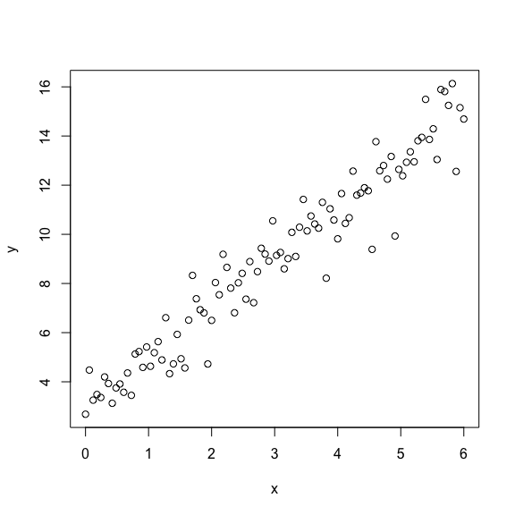

```r
> x<-seq(0,6, length=100)
>
> y<-2*x+3+rnorm(100)
>
> plot(x,y)
```

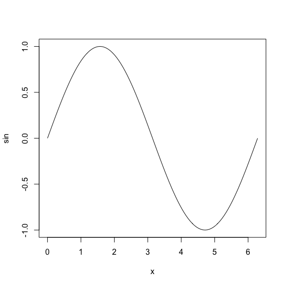

```r
>
> plot(sin,0,2*pi)
```

### 4.2.1 Export a plot to PDF

```r
> pdf("plotPDF.pdf")
> x <- rnorm(100)
> y <- x^2
> plot(x,y)
> dev.off()
## quartz_off_screen
##                 2
```

### 4.2.2 Export a plot to JPG

```r
> jpeg("plotJPG.jpg")
> x <- rnorm(100)
> y <- x^2
> plot(x,y)
> dev.off()
## quartz_off_screen
##                 2
```

### 4.2.3 Histogram and boxplot

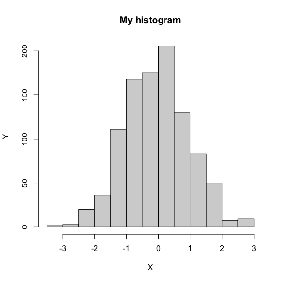

```r
> hist(rnorm(1000),main="My histogram", xlab="X",ylab="Y")
```

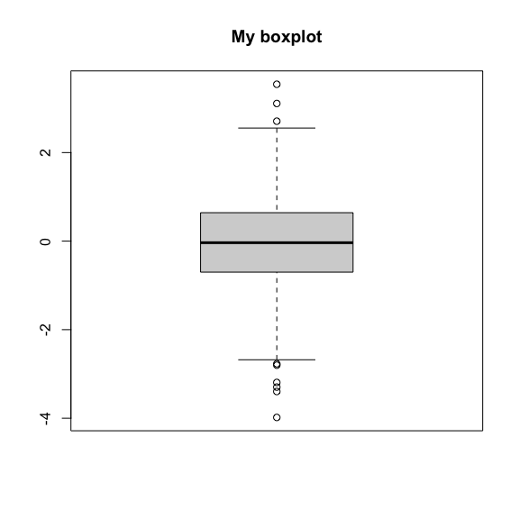

```r
> boxplot(rnorm(1000),main="My boxplot")
```

# 5 Loops and flow control

## 5.1 Loops with `for`

- In R the for loop is used perform a task for each element in a set. The syntax is:

```r
> for (var in num1:num2){
>   instruction1
>   instruction2
>   ...
> }
```

- Example:

```r
> y <- sample(1:5)
> z <- rep(1,5)
> for (i in 1:5){
+   z[i] <- y[i]^2
+ }
> z
```

```
## [1]  9 16 25  4  1
```

## 5.2 Flow control: if and if else statements

The syntax is:

```r
if (condition){
  expression_if_true else expression_if_false
}
```

- Example:

```r
> (x <- sample(1:3))
```

```
## [1] 3 1 2
```

```r
>
> if (x[1] < x[2] & x[2] < x[3]) print("Ordered vector") else
+     print(sort(x))
```

```
## [1] 1 2 3
```

```r
> (x <- 1:3)
```

```
## [1] 1 2 3
```

```r
>
> if (x[1] < x[2] & x[2] < x[3]) print("Ordered vector") else
+     print(sort(x))
```

```
## [1] "Ordered vector"
```

- Another example:

```r
> for(i in 1:3){
+   if (i == 2) print("The index is 2") else
+     print("The index is not 2")
+ }
```

```
## [1] "The index is not 2"
## [1] "The index is 2"
## [1] "The index is not 2"
```

- A shorter version…

```r
> ifelse(condition, expression_if_true, expression_if_false)
```

```r
> (x <- rnorm(2,0,1))
```

```
## [1] 1.1560831 0.5240157
```

```r
> ifelse(x[1] < x[2], "True", "False")
```

```
## [1] "False"
```

## 5.3 While loop example

- The while loop: `while(cond) expr`

```r
> x <- 1
> while (x < 5) {
+   x <- x+1
+   print(x)
+ }
```

```
## [1] 2
## [1] 3
## [1] 4
## [1] 5
```

```r
> x <- 1
> while (x < 5) {
+   print(x)
+   x <- x+1
+ }
```

```
## [1] 1
## [1] 2
## [1] 3
## [1] 4
```

# 6 Reading in data

- R can import data from (but not only):
  - Excel;
  - Plain text files;
  - SAS;
  - SPSS;
  - STATA;
  - etc.
- Typically, is easier to install a package to read in data. For instance, the package `Hmisc` contains functions that handles import from SPSS.

## 6.1 Reading data from user input

- Frequently, data is collected in white space separated columns, where the first line indicate the variable name (try to use the `scan()` function):

```r
> mydat<-data.frame(x1=c(2,2,3,3,1,1), x2=c(.3, 1, 2.1, 2.2, .1, .2), x3=0.01*c(1,11,4,2,10,6))
> mydat
```

```
##   x1  x2   x3
## 1  2 0.3 0.01
## 2  2 1.0 0.11
## 3  3 2.1 0.04
## 4  3 2.2 0.02
## 5  1 0.1 0.10
## 6  1 0.2 0.06
```

## 6.2 The R working directory

- R has a search path, the R working directory, where it stores its workspace and look for files. You can locate the working directory with the “get working directory” command:

```r
> getwd()
```

```
## [1] "/Users/nunobrites/Library/Mobile Documents/com~apple~CloudDocs/Aulas/ISEG/UCs/iDBA/Cohort3/Comp-Prob-Stats Nov2021/iDBA3cohort"
```

- The working directory can be changed with the “set working directory” command:

```r
> setwd("c:/otherdir")
```

- For files stored in the working directory or subfolders, you can just specify the path from the working directory when reading them. Example: if the data is located in the “Data” folder in your working directory, write:

```r
> mydat<-read.table("Data/filename.xyz")
```

## 6.3 Reading text files from Excel

- Install package `readxl` and use the `read_excel` function.

```r
> library(readxl)
> my_excel_data <- read_excel("Babies.xlsx", sheet= "Babies")
> my_excel_data <- as.data.frame(my_excel_data)
> my_excel_data
```

```
##     Age Male babies Female babies
## 1  1841       40.15         42.25
## 2  1842       40.07         41.92
## 3  1843       40.59         42.62
## 4  1844       40.20         42.28
## 5  1845       41.12         43.22
## 6  1846       39.08         41.22
## 7  1847       37.46         39.57
## 8  1848       38.81         40.97
## 9  1849       36.82         38.54
## 10 1850       41.83         43.71
## 11 1851       39.97         41.93
## 12 1852       39.35         41.47
## 13 1853       38.86         41.11
## 14 1854       38.52         40.44
```

[output cut: 25 more lines]

# 7 Simulation

## 7.1 Random numbers and probability distributions

- Simulation from a uniform distribution:

```r
> runif(5,min=1,max=2)
```

```
## [1] 1.260452 1.408064 1.613127 1.943788 1.135909
```

- Simulation from a normal distribution:

```r
> rnorm(5,mean=2,sd=1)
```

```
## [1] 1.949370 2.552687 0.908960 1.803383 1.550546
```

- Simulation from a gamma distribution:

```r
> rgamma(5,shape=2,rate=1)
```

```
## [1] 1.143402 2.469758 1.285959 1.582098 1.023291
```

- Simulation from a binomial distribution:

```r
> rbinom(5,size=100,prob=.3)
```

```
## [1] 31 35 25 28 29
```

- Simulation from a multinomial distribution:

```r
> rmultinom(5,size=100,prob=c(.3,.2,.5))
```

```
##      [,1] [,2] [,3] [,4] [,5]
## [1,]   28   37   29   31   30
## [2,]   20   14   17   26   20
## [3,]   52   49   54   43   50
```

- Distributions:

```r
> # normal: dnorm(x=..., mean=..., sd=...); x is a quatile.
> # dnorm(0,0,1) = 1/sqrt(2*pi)
> dnorm(0,0,1)
```

```
## [1] 0.3989423
```

```r
> dnorm(0,0,1) == 1/sqrt(2*pi)
```

```
## [1] TRUE
```

```r
>
> # normal: pnorm(q=..., mean=..., sd=...); q is a quatile.
> pnorm(0,0,1)
```

```
## [1] 0.5
```

```r
> pnorm(-1.96,0,1)
```

```
## [1] 0.0249979
```

```r
> pnorm(-1.64,0,1)
```

```
## [1] 0.05050258
```

```r
> pnorm(1.96,0,1)
```

```
## [1] 0.9750021
```

```r
> pnorm(1.64,0,1)
```

```
## [1] 0.9494974
```

```r
>
> # normal: qnorm(p=..., mean=..., sd=...); p is a probability.
> qnorm(0.5,0,1)
```

```
## [1] 0
```

```r
> qnorm(0.95,0,1)
```

```
## [1] 1.644854
```

```r
> qnorm(0.975,0,1)
```

```
## [1] 1.959964
```

## 7.2 Simulated normally distributed data - `rnorm()`

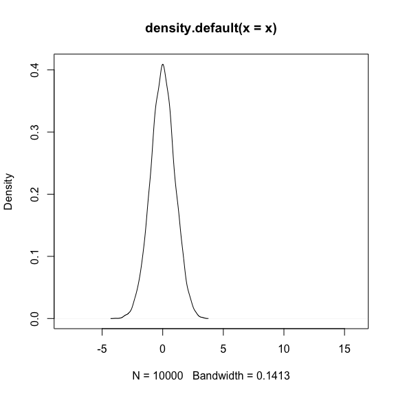

```r
> set.seed(12345)
>
> x<-rnorm(10000)
> plot(density(x),xlim=c(-8,16))
```

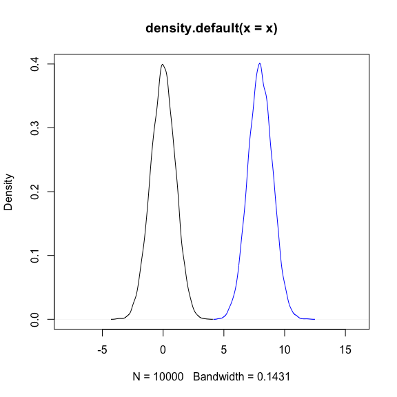

```r
> set.seed(54321)
>
> x<-rnorm(10000)
> plot(density(x),xlim=c(-8,16))
>
> y<-rnorm(10000,mean=8)
> lines(density(y),col="blue")
```

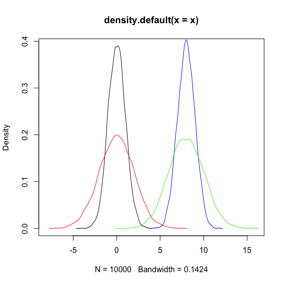

```r
> set.seed(123456)
>
> x<-rnorm(10000)
> plot(density(x),xlim=c(-8,16))
>
> y<-rnorm(10000,mean=8)
> lines(density(y),col="blue")
>
> lines(density(rnorm(10000,sd=2)),col="red")
> lines(density(rnorm(10000,mean=8,sd=2)),col="green")
```

# 8 Graphics in R

## 8.1 `base`

- The original (default) graphics system in R.
- Highly customizable.
- Complex plots require many code lines.

```r
> demo(graphics)
```

```r
> demo(persp)
```

- All the code. Try it!

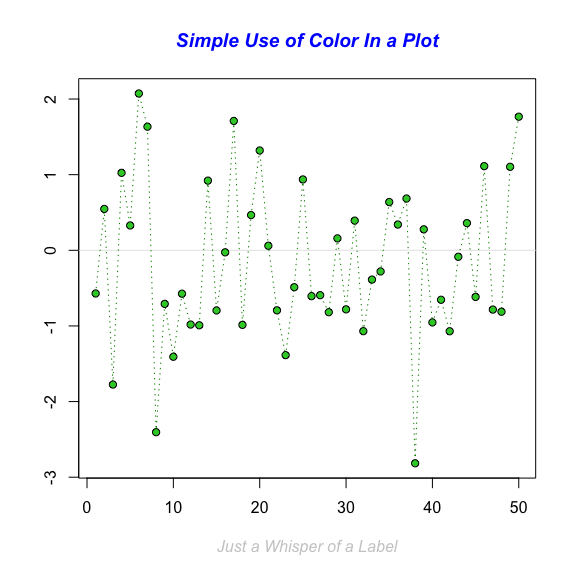

```r
> library(datasets)
> library(grDevices)
> library(graphics)
> library(gridGraphics)
>
>
> # demo1
> x <- stats::rnorm(50)
> par(bg = "white")
> plot(x, ann = FALSE, type = "n")
> abline(h = 0, col = gray(.90))
> lines(x, col = "green4", lty = "dotted")
> points(x, bg = "limegreen", pch = 21)
> title(main = "Simple Use of Color In a Plot",
+         xlab = "Just a Whisper of a Label",
+         col.main = "blue", col.lab = gray(.8),
+         cex.main = 1.2, cex.lab = 1.0, font.main = 4, font.lab = 3)
```

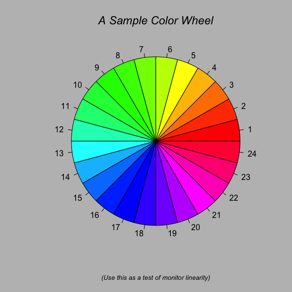

```r
>
> # demo2
> par(bg = "gray")
> pie(rep(1,24), col = rainbow(24), radius = 0.9)
> title(main = "A Sample Color Wheel", cex.main = 1.4, font.main = 3)
> title(xlab = "(Use this as a test of monitor linearity)", cex.lab = 0.8, font.lab = 3)
```

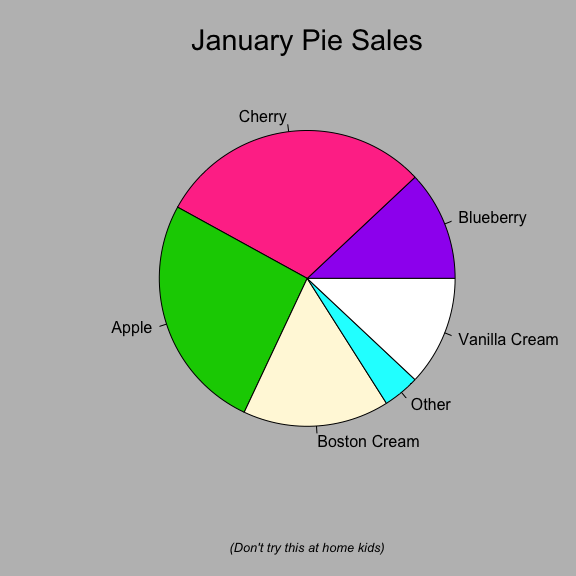

```r
>
> # demo3
> pie.sales <- c(0.12, 0.3, 0.26, 0.16, 0.04, 0.12)
> names(pie.sales) <- c("Blueberry", "Cherry","Apple", "Boston Cream", "Other", "Vanilla Cream")
> pie(pie.sales,col = c("purple","violetred1","green3","cornsilk","cyan","white"))
> title(main = "January Pie Sales", cex.main = 1.8, font.main = 1)
> title(xlab = "(Don't try this at home kids)", cex.lab = 0.8, font.lab = 3)
```

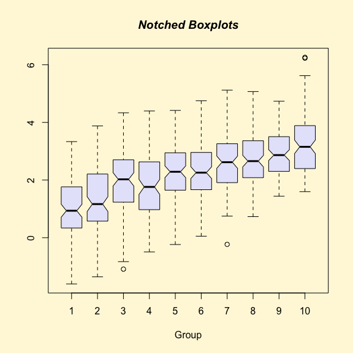

```r
>
> # demo4
> par(bg="cornsilk")
> n <- 10
> g <- gl(n, 100, n*100)
> x <- rnorm(n*100) + sqrt(as.numeric(g))
> boxplot(split(x,g), col="lavender", notch=TRUE)
> title(main="Notched Boxplots", xlab="Group", font.main=4, font.lab=1)
```

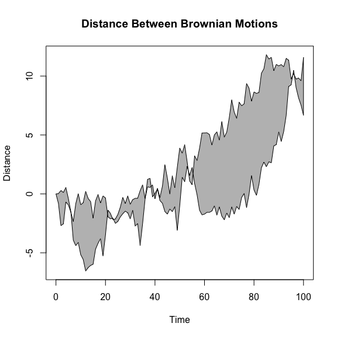

```r
>
> # demo5
> par(bg="white")
> n <- 100
> x <- c(0,cumsum(rnorm(n)))
> y <- c(0,cumsum(rnorm(n)))
> xx <- c(0:n, n:0)
> yy <- c(x, rev(y))
> plot(xx, yy, type="n", xlab="Time", ylab="Distance")
> polygon(xx, yy, col="gray")
> title("Distance Between Brownian Motions")
```